# Model diagnostics and model selection

## Overview of today’s material

- Diagnostics
- Approaches for model selection
- Cross validation
- Quantifying forecast performance

## Residual Diagnostics in State-Space Models

State-space models in `MARSS` assume:

- Observation equation: \(y_t = Zx_t + a + v_t\)
- State equation: \(x_t = bx_{t-1} + u + w_t\)

Where: - \(v_t \sim N(0, R)\): observation error - \(w_t \sim N(0, Q)\): process error

## What Types of Residuals Can We Get?

`MARSS()` provides:

- **Model residuals**: \[y_t - \hat{y}_t\]
  - How well the model predicts observations
- **State residuals**: \[x_t - E[x_t | y]\]
  - Deviations from estimated latent state

## Residuals workflow

- For each of model and state residuals
- Plot residuals vs time
- Check ACF/PACF for autocorrelation
- QQ plot + histogram for normality
- Formal tests (optional): Shapiro-Wilk, Ljung-Box

## Residuals workflow

- `DHARMa` package has great built in diagnostics
- Not compatible with simulation steps in MARSS
- But residual checks are straightforward and we can implement our own equivalents

## Example data: global ocean temperature anomalies

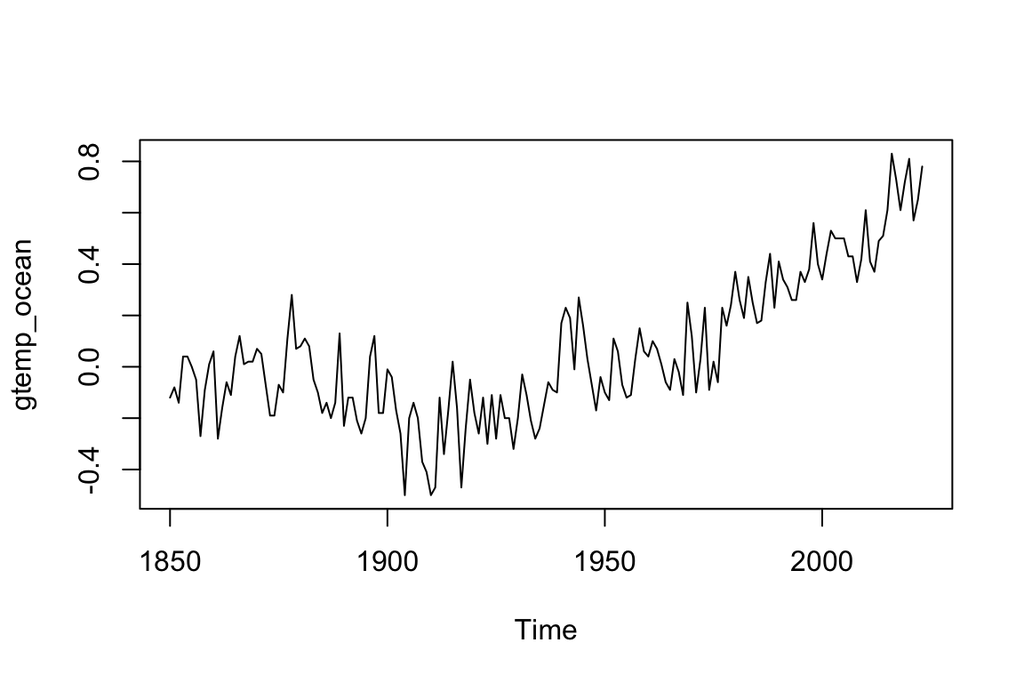

## Example data: global ocean temperature anomalies

- simple univariate state space model

```r
data("gtemp_ocean")
fit <- MARSS(gtemp_ocean)
```

## What Types of Residuals Can We Get?

- **Residuals**:

```r
resid <- MARSSresiduals(fit, type = c("tT", "tt1", "tt"),
                        normalize = FALSE)
```

Extract residuals of interest

- “tT” smoothed residuals conditioned on all data y
- “tt1” one-step ahead residuals, conditioned on data up to t-1 (innovation residuals)
- “tt” contemporaneous residuals conditioned on data up to time t

## Plotting model residuals

- Is there a trend? Are they stationary?

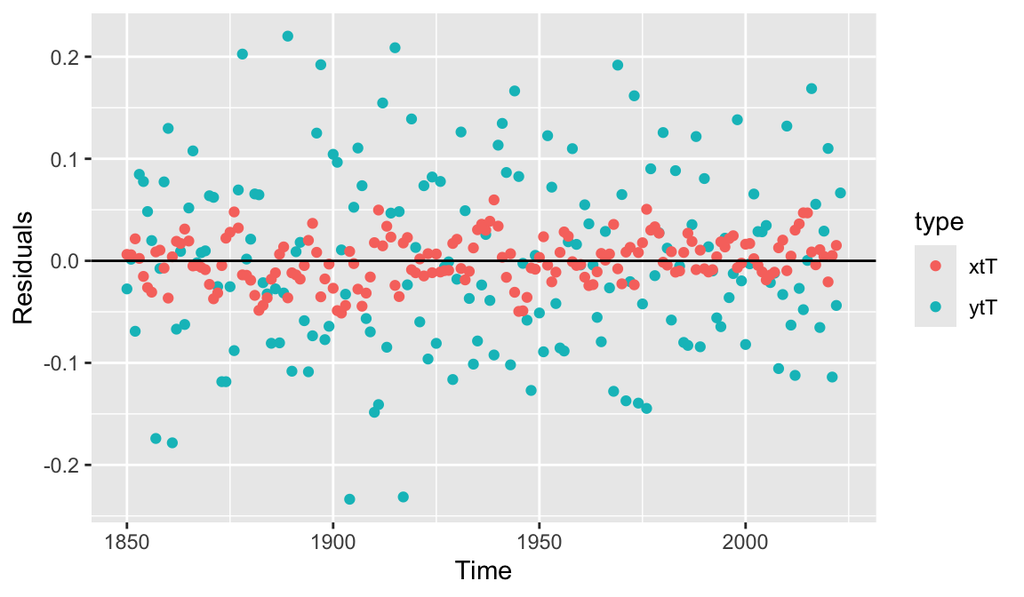

```r
resid_mod <- residuals(fit, type = "tT")
ggplot(resid_mod, aes(t, .resids, color = type)) +
  geom_point() + xlab("Time") + ylab("Residuals") +
  geom_hline(aes(yintercept = 0), col="black")
```

## ACFs and PCFs of residuals

- Spikes = autocorrelation

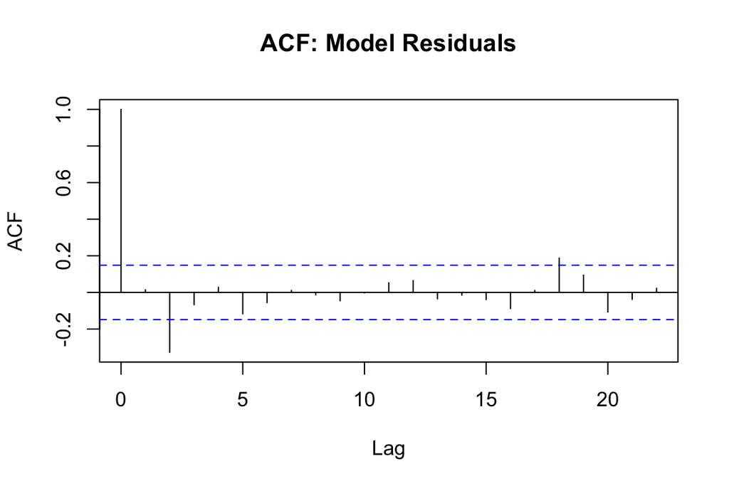

```r
resid1 <- resid_mod[(resid_mod$type=="ytT"),]
acf(resid1$.resids, main = "ACF: Model Residuals")
```

## ACFs and PCFs of residuals

- PACF at lag 2: maybe we’d be better off with AR(2) model?

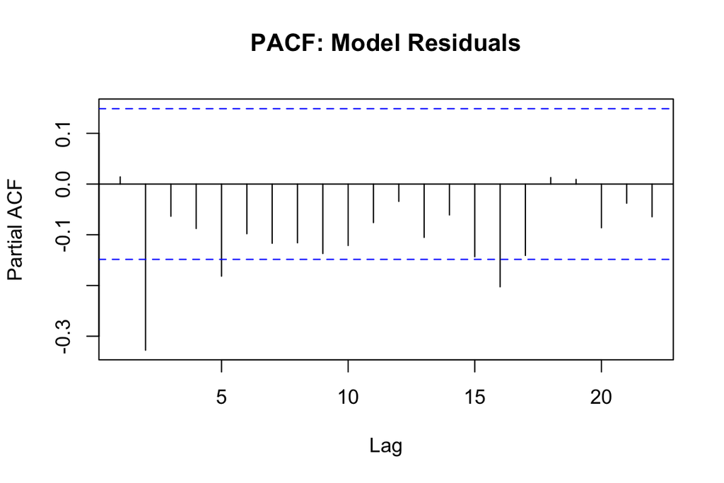

```r
resid1 <- resid_mod[(resid_mod$type=="ytT"),]
pacf(resid1$.resids, main = "PACF: Model Residuals")
```

## Normality checks

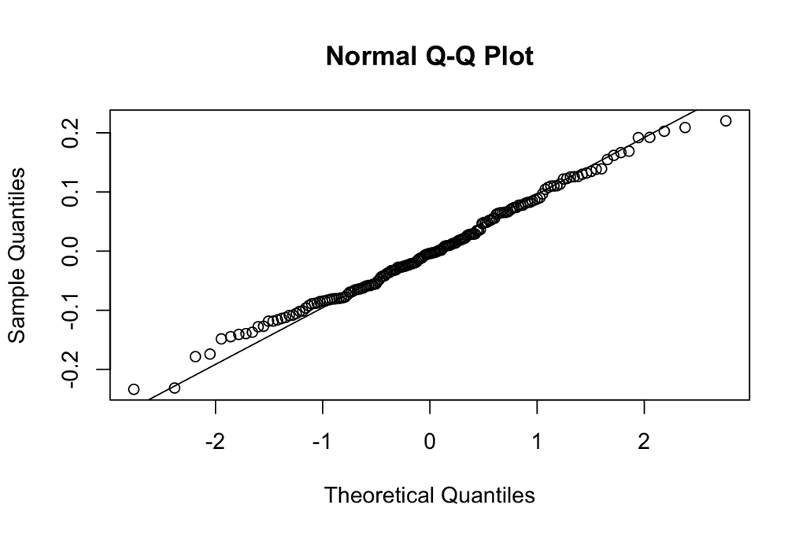

```r
qqnorm(resid1$.resid)
qqline(resid1$.resid)
```

## Normality checks

- Skewness or multimodality?

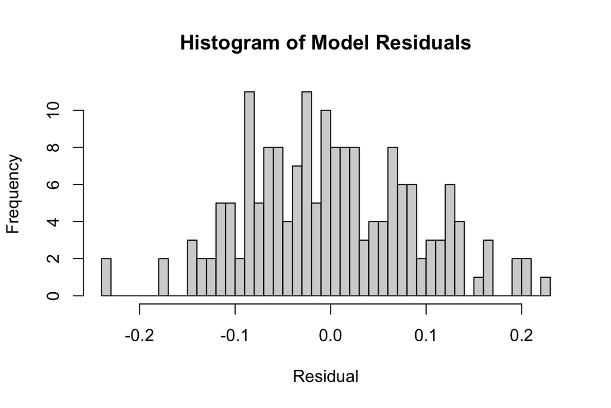

```r
hist(resid1$.resid, 40,
     main = "Histogram of Model Residuals", xlab = "Residual")
```

## Extensions for multivariate models

- All of the previous diagnostics are appropriate for multivariate models
- Are residuals correlated across multiple time series?
- Why might this occur and how to fix it?

## How good are our models?

Several candidate models might be built based on

- hypotheses / mechanisms
- diagnostics / summaries of fit

Models can be evaluated by their ability to explain data

- OR by the tradeoff in the ability to explain data, and ability to predict future data
- OR just in their predictive abilities
  - Hindcasting
  - Forecasting

## How good are our models?

We can illustrate with an example to the `harborSealWA` dataset in MARSS

\(y_{t} = b_{0}+b_{1}*t+e_{t}\)

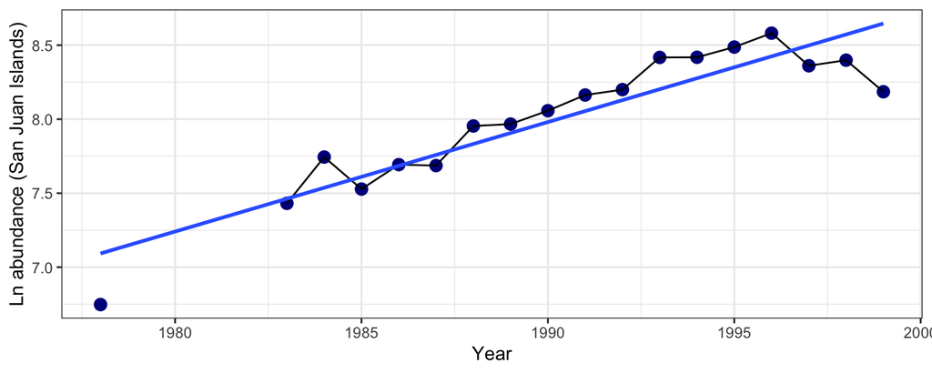

## How good are our models?

```
##
## Call:
## lm(formula = SJI ~ Year, data = harborSealWA)
##
## Residuals:
##      Min       1Q   Median       3Q      Max
## -0.46099 -0.08022  0.06576  0.13286  0.21464
##
## Coefficients:
##               Estimate Std. Error t value Pr(>|t|)
## (Intercept) -1.392e+02  1.601e+01  -8.697 1.85e-07 ***
## Year         7.397e-02  8.043e-03   9.197 8.69e-08 ***
## ---
## Signif. codes:  0 '***' 0.001 '**' 0.01 '*' 0.05 '.' 0.1 ' ' 1
##
## Residual standard error: 0.1916 on 16 degrees of freedom
##   (4 observations deleted due to missingness)
## Multiple R-squared:  0.8409, Adjusted R-squared:  0.831
## F-statistic: 84.58 on 1 and 16 DF,  p-value: 8.693e-08
```

## How good are our models?

Our regression model had a pretty good SS

\[SS=\sum _{ i=1 }^{ n }{ { \left( y_{ i }-E[{ y }_{ i }] \right) }^{ 2 } } \]

- But SS is problematic
  - as we consider more complex models, they’ll inevitably reduce SS
  - there’s no cost or penalty for having too many parameters

## Model selection

Lots of metrics have been developed to overcome this issue and penalize complex models

- **Occam’s razor**: “the law of briefness”
- **Principle of parsimony**: choose the simplest possible model that explains the data pretty well
  - choose a model that minimizes bias *and* variance

## Model selection

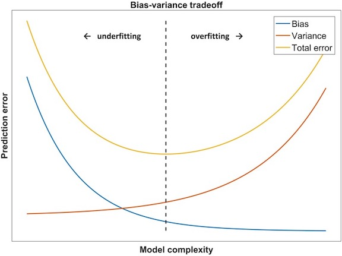

https://www.ncbi.nlm.nih.gov/books/NBK543534/figure/ch8.Fig3/

## Model selection: AIC

Akaike’s Information Criterion (**AIC**, Akaike 1973)

- Attempts to balance the goodness of fit of the model against the number of parameters
- Based on deviance = minus twice negative log likelihood

Deviance = \[-2\cdot ln\left( L(\underline { \theta } |\underline { y } ) \right)\]

- Deviance is a measure of model fit to data
  - lower values are better
  - Maximizing likelihood is equivalent to minimizing negative likelihood

## Model selection: AIC

- Why the large focus on AIC?
- Heavily used in ecology (Burnham and Anderson 2002)[https://www.springer.com/gp/book/9780387953649]
- Also the default in many stepwise model selection procedures in R
- [forecast](https://cran.r-project.org/web/packages/forecast/forecast.pdf), [glmulti](https://www.jstatsoft.org/article/view/v034i12/v34i12.pdf), [bestglm](https://cran.r-project.org/web/packages/bestglm/), [AICcmodavg](https://cran.r-project.org/web/packages/AICcmodavg/AICcmodavg.pdf), [MuMIn](https://cran.r-project.org/web/packages/MuMIn/MuMIn.pdf)

## Model selection: AIC

Many base functions in R support the extraction of AIC

```r
y = cumsum(rnorm(20))
AIC(lm(y~1))
AIC(glm(y~1))
AIC(mgcv::gam(y~1))
AIC(glmmTMB::glmmTMB(y~1))
AIC(lme4::lmer(y~1))
AIC(stats::arima(y))
AIC(forecast::Arima(y))
AIC(MARSS:MARSS(y))
```

## Model selection: AIC

Many *IC approaches to model selection also rely on deviance. Where they differ is how they structure the penalty term.

For AIC, the penalty is 2 * number of parameters (\(k\)),

\[AIC = -2\cdot ln\left( L(\underline { \theta } |\underline { y } ) \right) + 2k\]

- This is not affected by sample size, \(n\)

## Model selection: AIC

AIC aims to find the best model to predict data generated from the same process that generated your observations

- Equivalent to significance test w/ \(\alpha\) = 0.16

Alternative: Schwarz/Bayesian Information Criterion (SIC/BIC)

- Not Bayesian!
- Relies on Laplace approximation to posterior
- \(\alpha\) becomes a function of sample size

## Model selection: AIC

BIC is measure of explanatory power (rather than balancing explanation / prediction)

\[BIC = -2\cdot ln\left( L(\underline { \theta } |\underline { y } ) \right) + k\cdot ln(n)\]

## AIC and BIC for time series forecasting

- Smallest AIC similar to minimizing one-step ahead forecasts using MSE [Rob Hyndman’s blog](https://robjhyndman.com/hyndsight/aic/)
- AIC approximates LOOCV [Stone (1977)](https://www.jstor.org/stable/2984877?seq=1)
- BIC approximates k-fold cross validation [Shao (1997)](https://www.jstor.org/stable/24306073?seq=1)

## Bayesian model selection

The big difference between the Bayesian and maximum likelihood approaches are that

- ML methods are maximizing the likelihood over the parameter space
- Bayesian methods are integrating over the parameter space, asking ‘what values are best, on average?’

Many of the ML methods discussed were designed for models with only fixed effects.

- What about correlated parameters, nested or hierarchical models?

## Bayesian model selection

Again, lots of options that have evolved quickly over the last several decades

- Bayes factors (approximated by BIC)
  - can be very difficult to calculate for complex models
- Deviance Information Criterion (DIC)
  - Spiegelhalter et al. (2002)
  - DIC is easy to get out of some programs (JAGS)
- Widely applicable information criterion (WAIC)
  - [Watanabe (2010)](https://www.jmlr.org/papers/volume11/watanabe10a/watanabe10a.pdf)
- Leave One Out Information Criterion (LOOIC)
  - [Vehtari et al. 2017](https://link.springer.com/article/10.1007/s11222-016-9696-4), [Vehtari et al. 2019](https://arxiv.org/abs/1507.02646)

## Bridging ML / Bayesian model selection

J.T. Thorson 2024: Measuring complexity for hierarchical models using effective degrees of freedom

- similar to `mgcv` in that we can approximate the effective degrees of freedom
- but applied to models with random effects / hierarchical structure
- has generally not been available in maximum likelihood

## Cross validation

Recent focus in ecology & fisheries on prediction

[Dietze et al. 2017](https://esajournals.onlinelibrary.wiley.com/doi/full/10.1002/eap.1589)

[Maris et al. 2017](https://onlinelibrary.wiley.com/doi/full/10.1111/oik.04655)

[Pennekamp et al. 2017](https://www.sciencedirect.com/science/article/pii/S1476945X16301106)

[Pennekamp et al. 2018](https://www.biorxiv.org/content/early/2018/06/19/350017)

[Szuwalkski & Thorson 2017](https://onlinelibrary.wiley.com/doi/abs/10.1111/faf.12226)

[Anderson et al. 2017](https://onlinelibrary.wiley.com/doi/abs/10.1111/faf.12200)

## Resampling techniques

**Jackknife**

- Hold out each data point, recomputing some statistic (and then average across 1:n)

**Bootstrap**

- Similar to jackknife, but with resampling

**Cross-validation (k-fold)**

- Divide dataset into k-partitions
- How well do (k-1) partitions predict kth set of points?
- Relationship between LOOCV and AIC / BIC

**Data split**: test/training sets (e.g. holdout last 5 data pts)

## Resampling techniques: bootstrap

Bootstrap or jackknife approaches are useful

- generally used in the context of time series models to generate new or pseudo-datasets
- posterior predictive checks in Bayesian models generate new data from posterior draws
- state space models: use estimated deviations / errors to simulate, estimate CIs

Examples

```r
MARSS::MARSSboot()
MARSS::MARSSinnovationsboot()
forecast::bld.mbb.bootstrap()
forecast::forecast(..., bootstrap=TRUE)
```

## Resampling techniques: K-fold cross validation

As an example, we’ll use a time series of body temperature from the `beavers` dataset

```r
data(beavers)
beaver = dplyr::filter(beaver2, time>200)
```

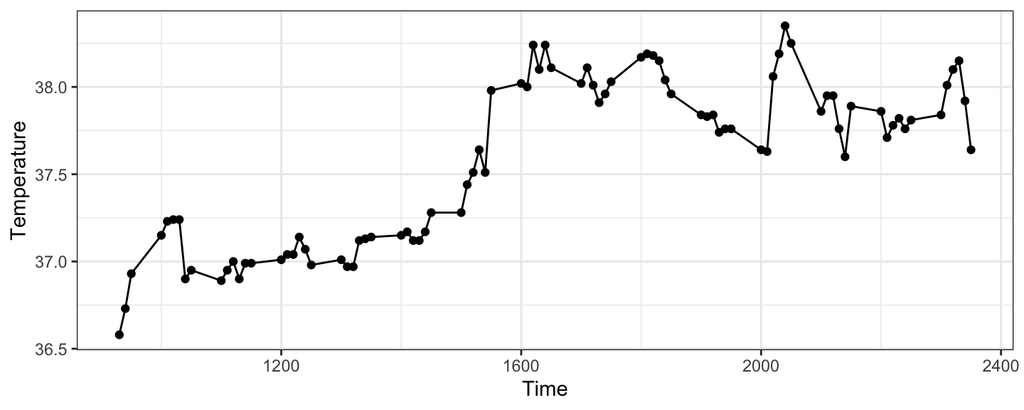

## Resampling techniques: K-fold cross validation

- Choose model (e.g. State space model w/MARSS)
- Partition data
- Fit & prediction

## Resampling techniques: K-fold cross validation

```r
set.seed(123)
K = 5
beaver$part = sample(1:K, size=nrow(beaver), replace=T)
beaver$pred = 0
beaver$pred_se = 0
for(k in 1:K) {
  y = beaver$temp
  y[which(beaver$part==k)] = NA
    mod = MARSS(y, model=list("B"="unequal"))
    beaver$pred[beaver$part==k] =
      mod$states[1,which(beaver$part==k)]
    beaver$pred_se[beaver$part==k] =
      mod$states.se[1,which(beaver$part==k)]
}
```

## Resampling techniques: K-fold cross validation

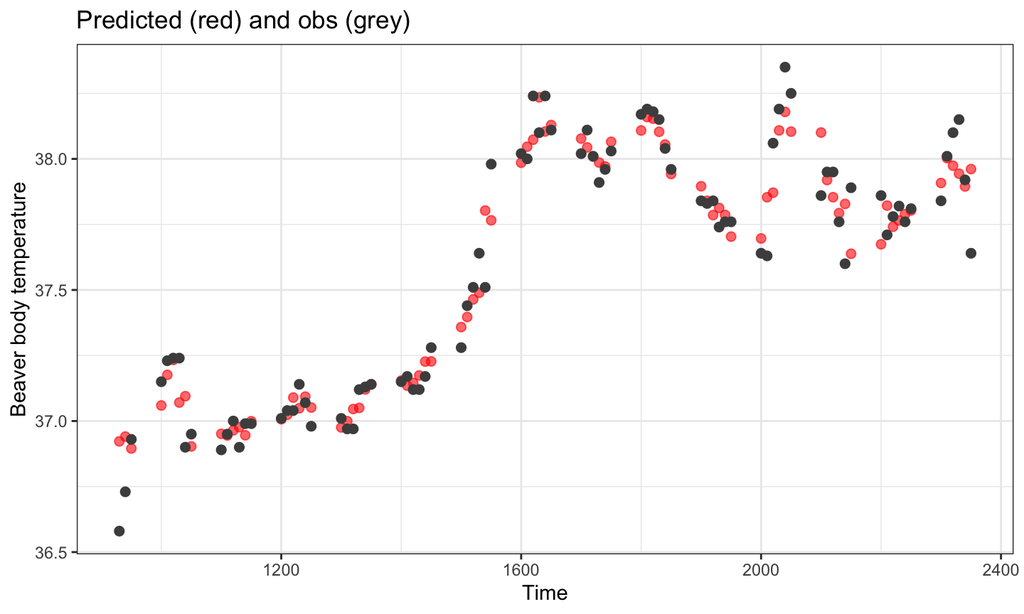

## Resampling techniques: K-fold cross validation

- How large should K be?
- Bias/variance tradeoff:
- Low K: low variance, larger bias, quicker to run. ML approaches recommend 5-10
- High K (LOOCV): low bias, high variance, computationally expensive

## Resampling techniques: K-fold cross validation

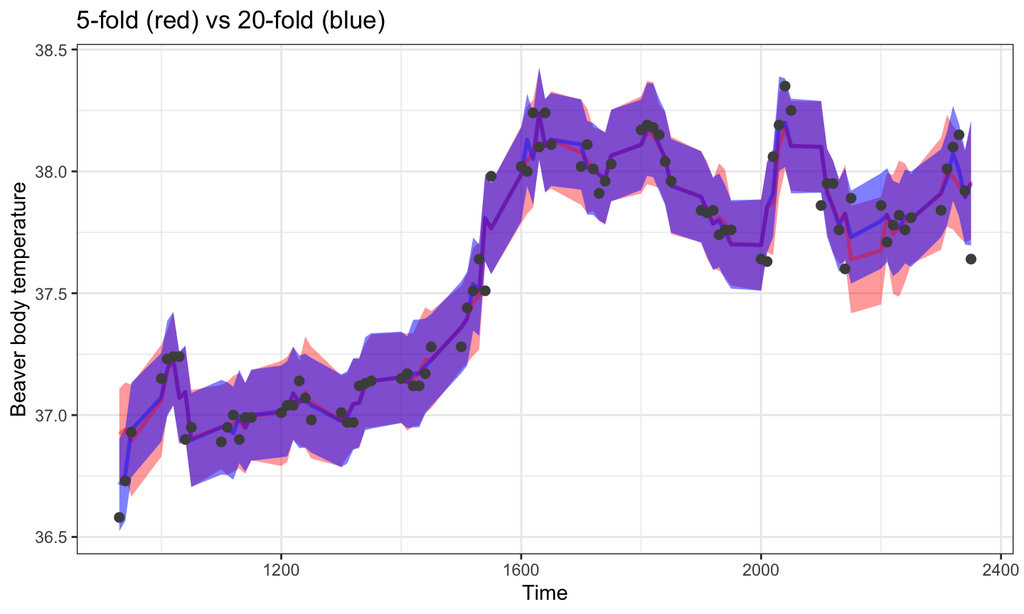

## Resampling techniques: repeated K-fold cross validation

- To remove effect of random sampling / partitioning, repeat K-fold cross validation and average predictions for a given data point
- caret() package in R does this for some classes of models
- [Data splitting for time series](https://topepo.github.io/caret/data-splitting.html#data-splitting-for-time-series)

## Resampling techniques: repeated K-fold cross validation

- Need to specify repeats

```r
train_control = caret::trainControl(method="repeatedcv",
                number=5, repeats=20)
```

- Again this is extendable across many widely used models

## Resampling techniques

What about for time series data?

- Previous resampling was random
- No preservation of order (autocorrelation)

## Resampling techniques: LTOCV

- Leave Time Out Cross Validation = leave each year out in turn
- Predict using historical and future data
- Re-analyze the beaver data using LTOCV

## Resampling techniques: future (aka forward chain) CV

Leave Future Out Cross Validation: only evaluate models on future data

- Fold 1: training[1], test[2]
- Fold 2: training[1:2], test[3]
- Fold 3: training[1:3], test[4]
- Fold 4: training[1:4], test[5]

## Resampling techniques: LFOCV

- Apply MARSS model to beaver dataset
- Assign partitions in order, 1:5

```r
beaver$part = ceiling(5*seq(1,nrow(beaver)) / (nrow(beaver)))
```

- iterate through 2:5 fitting the model and forecasting

## Resampling techniques: LFOCV

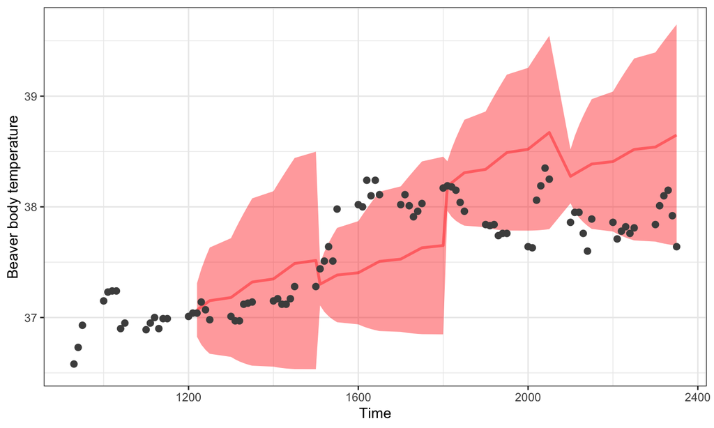

## Bayesian cross validation

LOOIC (Leave-one out cross validation) + preferred over alternatives

WAIC (widely applicable information criterion)

- Both available in `loo::loo()`

Additional reading: https://cran.r-project.org/web/packages/loo/vignettes/loo2-example.html

## Prediction and forecast evaluations

- Let’s fit an ARMA(1,1) model to the global temperature data, after 1st differencing to remove trend

## Prediction and forecast evaluations

- All models will have forecast uncertainty increase with time
- Rate of increase depends on the model

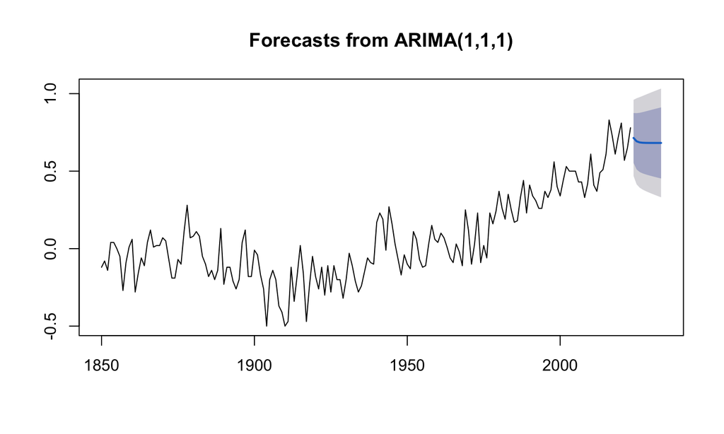

```r
plot(f1)
```

## Quantifying forecast performance

One of the most widelty used metrics is mean square error (MSE)

\[MSE=E\left[ { e }_{ t }^{ 2 } \right] =E\left[ { \left( { x }_{ t }-{ \hat { x } }_{ t } \right) }^{ 2 } \right]\]

- Root mean squared error (RMSE) also very common

## Quantifying forecast performance

Like with model selection, the bias-variance tradeoff is important

- principle of parsimony

MSE can be rewritten as

\[MSE=Var\left( { \hat { x } }_{ t } \right) +Bias{ \left( { x }_{ t },{ \hat { x } }_{ t } \right) }^{ 2 }\] * Smaller MSE = lower bias + variance

## Quantifying forecast performance

MSE and all forecast metrics can be calculated for

- single data points
- entire time series
- future forecasts

\[MSE={ \frac { \sum _{ t=1 }^{ n }{ { \left( { x }_{ t }-{ \hat { x } }_{ t } \right) }^{ 2 } } }{ n } }\]

- Do you care just about predicting the final outcome of a forecast, or also the trajectory to get there?

## Variants of MSE

Root mean square error, RMSE (quadratic score)

Mean absolute error, MAE (linear score) \[E\left[ \left| { x }_{ t }-{ \hat { x } }_{ t } \right| \right]\]

Median absolute error, MdAE

\[median\left[ \left| { x }_{ t }-{ \hat { x } }_{ t } \right| \right]\]

## Scale independent measures of performance

Better when applying statistics of model(s) to multiple datasets MSE or RMSE will be driven by time series that is larger in magnitude

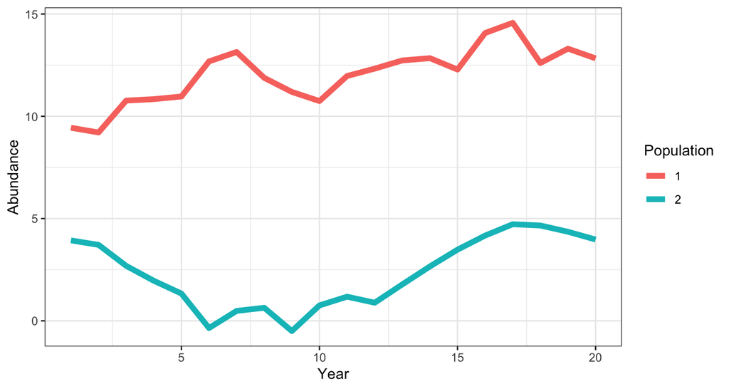

## Percent Error Statistics

Percent Error:

\[{ p }_{ t }=\frac { { e }_{ t }\cdot 100 }{ { Y }_{ t } }\]

Mean Absolute Percent Error (MAPE):

\[MAPE\quad =\quad E\left[ \left| { p }_{ t } \right| \right]\] Root Mean Square Percent Error (RMSPE):

\[RMSPE\quad =\quad \sqrt { E\left[ { p }_{ t }^{ 2 } \right] }\]

## Issues with percent error statistics

\[{ p }_{ t }=\frac { { e }_{ t }\cdot 100 }{ { Y }_{ t } }\]

- What happens when Y = 0?
- Distribution of percent errors tends to be highly skewed / long tails
- MAPE tends to put higher penalty on positive errors
- See Hyndman & Koehler (2006)

## Scaled error statistics

Define scaled error as

\[{ q }_{ t }=\frac { { e }_{ t } }{ \frac { 1 }{ n-1 } \sum _{ i=2 }^{ n }{ \left( { Y }_{ i }-{ Y }_{ i-1 } \right) } }\]

- denominator is MAE from random walk model, so performance is gauged relative to that
- this does not allow for missing data

Absolute scaled error (ASE)

\[ASE=\left| { q }_{ t } \right|\] Mean absolute scaled error (MASE)

\[MASE=E\left[ \left| { q }_{ t } \right| \right]\]

## Interpreting ASE and MASE

All values are relative to the naïve random walk model

- Values < 1 indicate better performance than RW model
- Values > 1 indicate worse performance than RW model

## Implementation in R

- Fit an ARIMA model to ‘airmiles’,holding out last 3 points

```r
n = length(airmiles)
air.model = auto.arima(log(airmiles[1:(n-3)]))
```

## Implementation in R

- Forecast the fitted model 3 steps ahead
- Use holdout data to evaluate accuracy

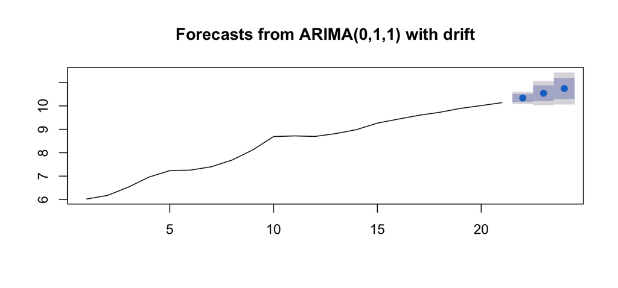

```r
air.forecast = forecast(air.model, h = 3)
plot(air.forecast)
```

## Implementation in R

Evaluate RMSE / MASE statistics for 3 holdouts

```r
accuracy(air.forecast, log(airmiles[(n-2):n]), test = 3)
```

```
##                  ME      RMSE       MAE       MPE     MAPE     MASE
## Test set -0.4183656 0.4183656 0.4183656 -4.051598 4.051598 2.010664
```

```r
accuracy(air.forecast, log(airmiles[(n-2):n]), test = 1)
```

```
##                  ME      RMSE       MAE       MPE     MAPE     MASE
## Test set -0.1987598 0.1987598 0.1987598 -1.960106 1.960106 0.955239
```

## MSE vs MAPE vs MASE

Raw statistics (e.g. MSE, RMSE) shouldn’t be applied for data of different scale

Percent error metrics (e.g. MAPE) may be skewed & undefined for real zeroes

Scaled error metrics (ASE, MASE) have been shown to be more robust meta-analyses of many datasets + Hyndman & Koehler (2006)

## Scoring rules

- Metrics (RMSE, etc.) evaluate point estimates of predictions vs. observations
- But what if we also care about how uncertain our predictions / forecasts are?
- limited to applications of parametric methods
- Scoring rules
- [Draper (2005)](https://users.soe.ucsc.edu/~draper/draper-BMIP-dec2005.pdf)
- [Gneting and Raftery (2012)](https://www.tandfonline.com/doi/abs/10.1198/016214506000001437)
- R packages: [scoring](https://cran.r-project.org/web/packages/scoring/scoring.pdf), [scoringRules](https://cran.r-project.org/web/packages/scoringRules/scoringRules.pdf)

## Scoring rules

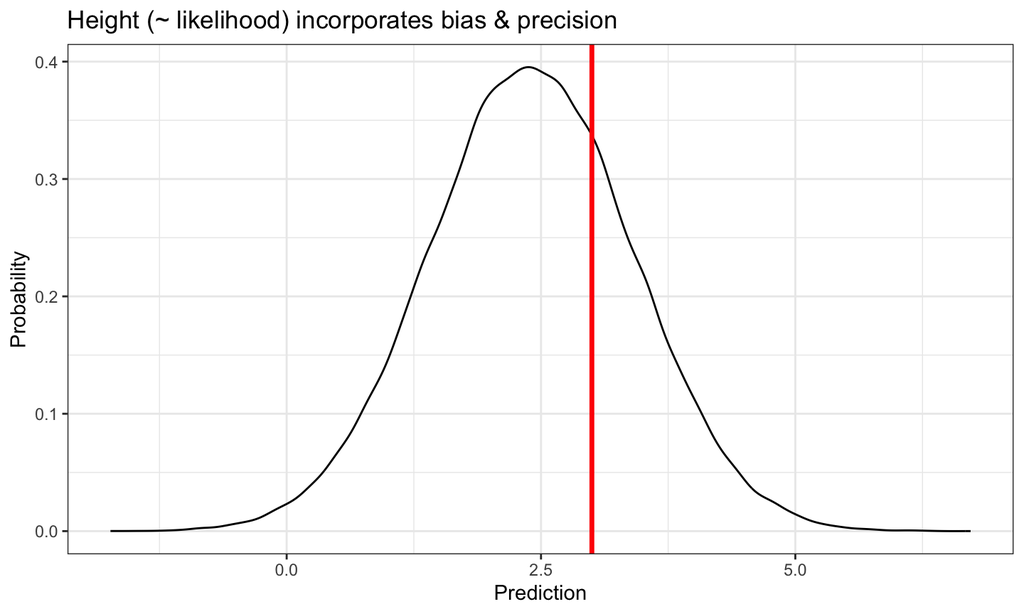

## Scoring rules

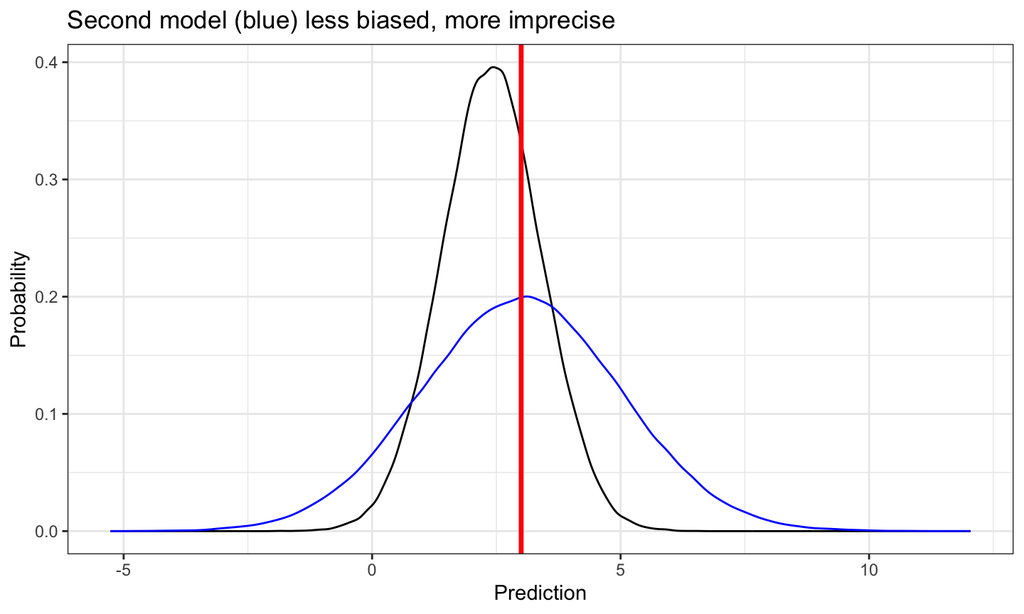